# Risk Factor Analysis

## Outcome Variable

**Outcome Variable:** stunted

## Predictor Variables

**Intervention Variable:** nchldlt5

**Adjustment Set:**

- arm
- W_mage
- meducyrs
- feducyrs
- hhwealth_quart
- hfoodsec
- W_mhtcm
- W_mwtkg
- W_mbmi
- W_nrooms
- W_parity
- impfloor
- impsan
- safeh20
- delta_W_mage
- delta_meducyrs
- delta_feducyrs
- delta_hhwealth_quart
- delta_hfoodsec
- delta_W_mhtcm
- delta_W_mwtkg
- delta_W_mbmi
- delta_W_nrooms
- delta_W_parity
- delta_impfloor
- delta_impsan
- delta_safeh20

## Stratifying Variables

The analysis was stratified on these variable(s):

- agecat
- studyid
- country

## Data Summary

| agecat | studyid | country | nchldlt5 | stunted | n_cell | n |
| --- | --- | --- | --- | --- | --- | --- |
| Birth | ki1000108-IRC | INDIA | 1 | 0 | 72 | 388 |
| Birth | ki1000108-IRC | INDIA | 1 | 1 | 12 | 388 |
| Birth | ki1000108-IRC | INDIA | 2+ | 0 | 271 | 388 |
| Birth | ki1000108-IRC | INDIA | 2+ | 1 | 33 | 388 |
| Birth | ki1017093b-PROVIDE | BANGLADESH | 1 | 0 | 354 | 539 |
| Birth | ki1017093b-PROVIDE | BANGLADESH | 1 | 1 | 37 | 539 |
| Birth | ki1017093b-PROVIDE | BANGLADESH | 2+ | 0 | 137 | 539 |
| Birth | ki1017093b-PROVIDE | BANGLADESH | 2+ | 1 | 11 | 539 |
| Birth | ki1017093c-NIH-Crypto | BANGLADESH | 1 | 0 | 449 | 732 |
| Birth | ki1017093c-NIH-Crypto | BANGLADESH | 1 | 1 | 73 | 732 |
| Birth | ki1017093c-NIH-Crypto | BANGLADESH | 2+ | 0 | 182 | 732 |
| Birth | ki1017093c-NIH-Crypto | BANGLADESH | 2+ | 1 | 28 | 732 |
| Birth | kiGH5241-JiVitA-3 | BANGLADESH | 1 | 0 | 9011 | 22431 |
| Birth | kiGH5241-JiVitA-3 | BANGLADESH | 1 | 1 | 4975 | 22431 |
| Birth | kiGH5241-JiVitA-3 | BANGLADESH | 2+ | 0 | 6039 | 22431 |
| Birth | kiGH5241-JiVitA-3 | BANGLADESH | 2+ | 1 | 2406 | 22431 |
| 6 months | ki1000108-IRC | INDIA | 1 | 0 | 67 | 407 |
| 6 months | ki1000108-IRC | INDIA | 1 | 1 | 22 | 407 |
| 6 months | ki1000108-IRC | INDIA | 2+ | 0 | 240 | 407 |
| 6 months | ki1000108-IRC | INDIA | 2+ | 1 | 78 | 407 |
| 6 months | ki1017093b-PROVIDE | BANGLADESH | 1 | 0 | 368 | 604 |
| 6 months | ki1017093b-PROVIDE | BANGLADESH | 1 | 1 | 70 | 604 |
| 6 months | ki1017093b-PROVIDE | BANGLADESH | 2+ | 0 | 140 | 604 |
| 6 months | ki1017093b-PROVIDE | BANGLADESH | 2+ | 1 | 26 | 604 |
| 6 months | ki1017093c-NIH-Crypto | BANGLADESH | 1 | 0 | 400 | 715 |
| 6 months | ki1017093c-NIH-Crypto | BANGLADESH | 1 | 1 | 107 | 715 |
| 6 months | ki1017093c-NIH-Crypto | BANGLADESH | 2+ | 0 | 165 | 715 |
| 6 months | ki1017093c-NIH-Crypto | BANGLADESH | 2+ | 1 | 43 | 715 |
| 6 months | ki1066203-TanzaniaChild2 | TANZANIA, UNITED REPUBLIC OF | 1 | 0 | 1267 | 2020 |
| 6 months | ki1066203-TanzaniaChild2 | TANZANIA, UNITED REPUBLIC OF | 1 | 1 | 124 | 2020 |
| 6 months | ki1066203-TanzaniaChild2 | TANZANIA, UNITED REPUBLIC OF | 2+ | 0 | 558 | 2020 |
| 6 months | ki1066203-TanzaniaChild2 | TANZANIA, UNITED REPUBLIC OF | 2+ | 1 | 71 | 2020 |
| 6 months | ki1148112-LCNI-5 | MALAWI | 1 | 0 | 263 | 811 |
| 6 months | ki1148112-LCNI-5 | MALAWI | 1 | 1 | 127 | 811 |
| 6 months | ki1148112-LCNI-5 | MALAWI | 2+ | 0 | 253 | 811 |
| 6 months | ki1148112-LCNI-5 | MALAWI | 2+ | 1 | 168 | 811 |
| 6 months | kiGH5241-JiVitA-3 | BANGLADESH | 1 | 0 | 8093 | 16800 |
| 6 months | kiGH5241-JiVitA-3 | BANGLADESH | 1 | 1 | 2794 | 16800 |
| 6 months | kiGH5241-JiVitA-3 | BANGLADESH | 2+ | 0 | 4484 | 16800 |
| 6 months | kiGH5241-JiVitA-3 | BANGLADESH | 2+ | 1 | 1429 | 16800 |
| 24 months | ki1000108-IRC | INDIA | 1 | 0 | 58 | 409 |
| 24 months | ki1000108-IRC | INDIA | 1 | 1 | 31 | 409 |
| 24 months | ki1000108-IRC | INDIA | 2+ | 0 | 179 | 409 |
| 24 months | ki1000108-IRC | INDIA | 2+ | 1 | 141 | 409 |
| 24 months | ki1017093b-PROVIDE | BANGLADESH | 1 | 0 | 299 | 578 |
| 24 months | ki1017093b-PROVIDE | BANGLADESH | 1 | 1 | 125 | 578 |
| 24 months | ki1017093b-PROVIDE | BANGLADESH | 2+ | 0 | 89 | 578 |
| 24 months | ki1017093b-PROVIDE | BANGLADESH | 2+ | 1 | 65 | 578 |
| 24 months | ki1017093c-NIH-Crypto | BANGLADESH | 1 | 0 | 276 | 514 |
| 24 months | ki1017093c-NIH-Crypto | BANGLADESH | 1 | 1 | 81 | 514 |
| 24 months | ki1017093c-NIH-Crypto | BANGLADESH | 2+ | 0 | 106 | 514 |
| 24 months | ki1017093c-NIH-Crypto | BANGLADESH | 2+ | 1 | 51 | 514 |
| 24 months | ki1066203-TanzaniaChild2 | TANZANIA, UNITED REPUBLIC OF | 1 | 0 | 4 | 6 |
| 24 months | ki1066203-TanzaniaChild2 | TANZANIA, UNITED REPUBLIC OF | 1 | 1 | 1 | 6 |
| 24 months | ki1066203-TanzaniaChild2 | TANZANIA, UNITED REPUBLIC OF | 2+ | 0 | 1 | 6 |
| 24 months | ki1066203-TanzaniaChild2 | TANZANIA, UNITED REPUBLIC OF | 2+ | 1 | 0 | 6 |
| 24 months | ki1148112-LCNI-5 | MALAWI | 1 | 0 | 161 | 571 |
| 24 months | ki1148112-LCNI-5 | MALAWI | 1 | 1 | 122 | 571 |
| 24 months | ki1148112-LCNI-5 | MALAWI | 2+ | 0 | 158 | 571 |
| 24 months | ki1148112-LCNI-5 | MALAWI | 2+ | 1 | 130 | 571 |
| 24 months | kiGH5241-JiVitA-3 | BANGLADESH | 1 | 0 | 2889 | 8622 |
| 24 months | kiGH5241-JiVitA-3 | BANGLADESH | 1 | 1 | 2565 | 8622 |
| 24 months | kiGH5241-JiVitA-3 | BANGLADESH | 2+ | 0 | 1499 | 8622 |
| 24 months | kiGH5241-JiVitA-3 | BANGLADESH | 2+ | 1 | 1669 | 8622 |

The following strata were considered:

- agecat: 24 months, studyid: ki1000108-IRC, country: INDIA
- agecat: 24 months, studyid: ki1017093b-PROVIDE, country: BANGLADESH
- agecat: 24 months, studyid: ki1017093c-NIH-Crypto, country: BANGLADESH
- agecat: 24 months, studyid: ki1066203-TanzaniaChild2, country: TANZANIA, UNITED REPUBLIC OF
- agecat: 24 months, studyid: ki1148112-LCNI-5, country: MALAWI
- agecat: 24 months, studyid: kiGH5241-JiVitA-3, country: BANGLADESH
- agecat: 6 months, studyid: ki1000108-IRC, country: INDIA
- agecat: 6 months, studyid: ki1017093b-PROVIDE, country: BANGLADESH
- agecat: 6 months, studyid: ki1017093c-NIH-Crypto, country: BANGLADESH
- agecat: 6 months, studyid: ki1066203-TanzaniaChild2, country: TANZANIA, UNITED REPUBLIC OF
- agecat: 6 months, studyid: ki1148112-LCNI-5, country: MALAWI
- agecat: 6 months, studyid: kiGH5241-JiVitA-3, country: BANGLADESH
- agecat: Birth, studyid: ki1000108-IRC, country: INDIA
- agecat: Birth, studyid: ki1017093b-PROVIDE, country: BANGLADESH
- agecat: Birth, studyid: ki1017093c-NIH-Crypto, country: BANGLADESH
- agecat: Birth, studyid: kiGH5241-JiVitA-3, country: BANGLADESH

### Dropped Strata

Some strata were dropped due to rare outcomes:

- agecat: 24 months, studyid: ki1066203-TanzaniaChild2, country: TANZANIA, UNITED REPUBLIC OF

## Methods Detail

We’re interested in the causal parameters $E[Y_a]$ for all values of $a \in \mathcal{A}$. These parameters represent the mean outcome if, possibly contrary to fact, we intervened to set all units to have $A=a$. Under the randomization and positivity assumptions, these are identified by the statistical parameters $\psi_a=E_W[E_{Y|A,W}(Y|A=a,W)]$. In addition, we’re interested in the mean of $Y$, $E[Y]$ under no intervention (the observed mean). We will estimate these parameters by using SuperLearner to fit the relevant likelihood factors – $E_{Y|A,W}(Y|A=a,W)$ and $p(A=a|W)$, and then updating our likelihood fit using a joint TMLE.

For unadjusted analyses ($W=\{\}$), initial likelihoods were estimated using Lrnr_glm to estimate the simple $E(Y|A)$ and Lrnr_mean to estimate $p(A)$. For adjusted analyses, a small library containing Lrnr_glmnet, Lrnr_xgboost, and Lrnr_mean was used.

Having estimated these parameters, we will then use the delta method to estimate relative risks and attributable risks relative to a prespecified baseline level of $A$.

# Results Detail

## Results Plots

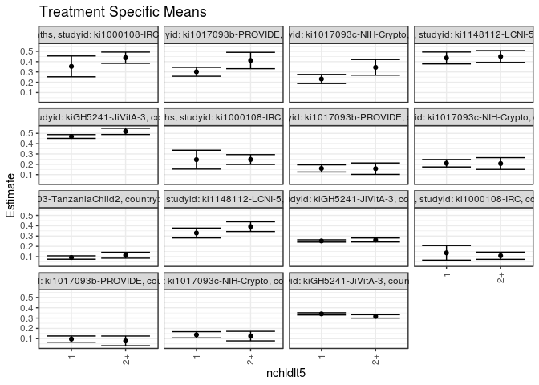

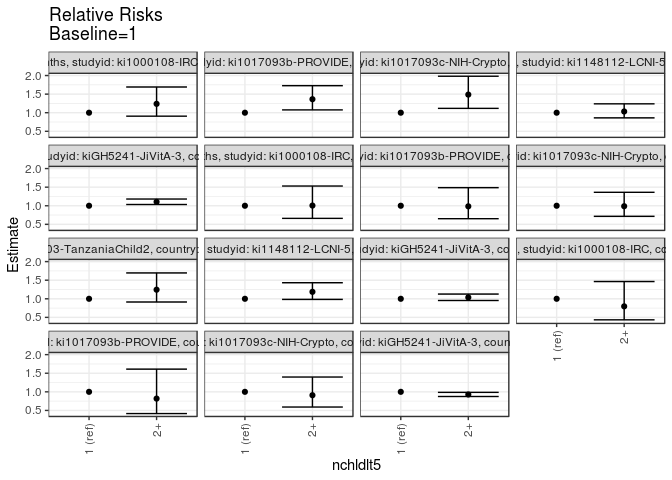

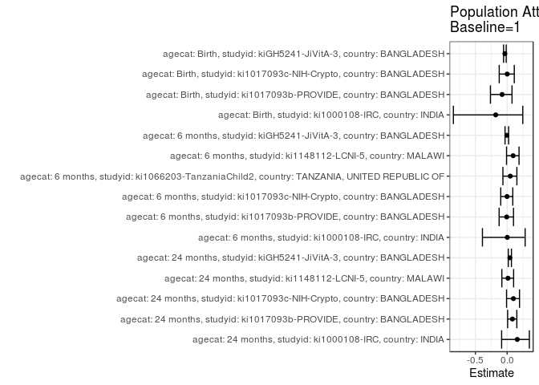

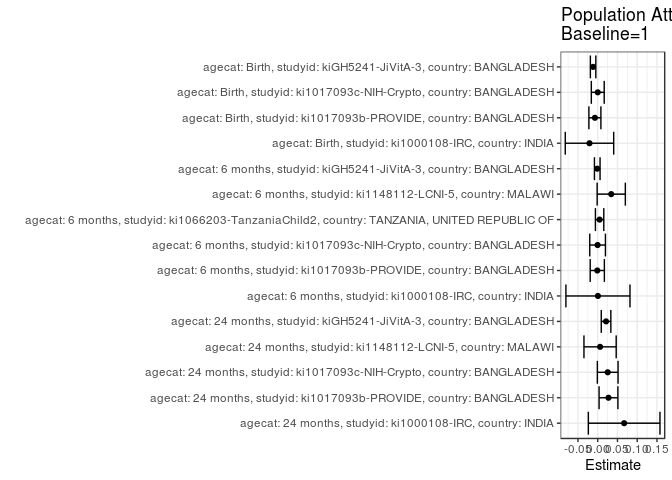

## Results Table

### Parameter: TSM

| agecat | studyid | country | intervention_level | baseline_level | estimate | ci_lower | ci_upper |
| --- | --- | --- | --- | --- | --- | --- | --- |
| Birth | ki1000108-IRC | INDIA | 1 | NA | 0.1368091 | 0.0662926 | 0.2073256 |
| Birth | ki1000108-IRC | INDIA | 2+ | NA | 0.1089748 | 0.0739710 | 0.1439786 |
| Birth | ki1017093b-PROVIDE | BANGLADESH | 1 | NA | 0.0961585 | 0.0660224 | 0.1262946 |
| Birth | ki1017093b-PROVIDE | BANGLADESH | 2+ | NA | 0.0786661 | 0.0314761 | 0.1258560 |
| Birth | ki1017093c-NIH-Crypto | BANGLADESH | 1 | NA | 0.1378463 | 0.1079108 | 0.1677818 |
| Birth | ki1017093c-NIH-Crypto | BANGLADESH | 2+ | NA | 0.1252454 | 0.0787589 | 0.1717318 |
| Birth | kiGH5241-JiVitA-3 | BANGLADESH | 1 | NA | 0.3407449 | 0.3298995 | 0.3515904 |
| Birth | kiGH5241-JiVitA-3 | BANGLADESH | 2+ | NA | 0.3161998 | 0.2995241 | 0.3328756 |
| 6 months | ki1000108-IRC | INDIA | 1 | NA | 0.2451205 | 0.1536001 | 0.3366408 |
| 6 months | ki1000108-IRC | INDIA | 2+ | NA | 0.2463661 | 0.1988448 | 0.2938874 |
| 6 months | ki1017093b-PROVIDE | BANGLADESH | 1 | NA | 0.1600013 | 0.1256118 | 0.1943909 |
| 6 months | ki1017093b-PROVIDE | BANGLADESH | 2+ | NA | 0.1575050 | 0.1021189 | 0.2128912 |
| 6 months | ki1017093c-NIH-Crypto | BANGLADESH | 1 | NA | 0.2100753 | 0.1741077 | 0.2460429 |
| 6 months | ki1017093c-NIH-Crypto | BANGLADESH | 2+ | NA | 0.2073812 | 0.1504220 | 0.2643405 |
| 6 months | ki1066203-TanzaniaChild2 | TANZANIA, UNITED REPUBLIC OF | 1 | NA | 0.0917361 | 0.0753346 | 0.1081375 |
| 6 months | ki1066203-TanzaniaChild2 | TANZANIA, UNITED REPUBLIC OF | 2+ | NA | 0.1141714 | 0.0853502 | 0.1429926 |
| 6 months | ki1148112-LCNI-5 | MALAWI | 1 | NA | 0.3294898 | 0.2818595 | 0.3771202 |
| 6 months | ki1148112-LCNI-5 | MALAWI | 2+ | NA | 0.3910783 | 0.3438491 | 0.4383075 |
| 6 months | kiGH5241-JiVitA-3 | BANGLADESH | 1 | NA | 0.2525403 | 0.2415197 | 0.2635608 |
| 6 months | kiGH5241-JiVitA-3 | BANGLADESH | 2+ | NA | 0.2617665 | 0.2421878 | 0.2813452 |
| 24 months | ki1000108-IRC | INDIA | 1 | NA | 0.3536007 | 0.2525058 | 0.4546956 |
| 24 months | ki1000108-IRC | INDIA | 2+ | NA | 0.4378986 | 0.3833345 | 0.4924628 |
| 24 months | ki1017093b-PROVIDE | BANGLADESH | 1 | NA | 0.3014463 | 0.2582028 | 0.3446897 |
| 24 months | ki1017093b-PROVIDE | BANGLADESH | 2+ | NA | 0.4109547 | 0.3316341 | 0.4902754 |
| 24 months | ki1017093c-NIH-Crypto | BANGLADESH | 1 | NA | 0.2315146 | 0.1875106 | 0.2755187 |
| 24 months | ki1017093c-NIH-Crypto | BANGLADESH | 2+ | NA | 0.3443467 | 0.2683216 | 0.4203718 |
| 24 months | ki1148112-LCNI-5 | MALAWI | 1 | NA | 0.4353565 | 0.3776420 | 0.4930711 |
| 24 months | ki1148112-LCNI-5 | MALAWI | 2+ | NA | 0.4498293 | 0.3925606 | 0.5070979 |
| 24 months | kiGH5241-JiVitA-3 | BANGLADESH | 1 | NA | 0.4699379 | 0.4516594 | 0.4882163 |
| 24 months | kiGH5241-JiVitA-3 | BANGLADESH | 2+ | NA | 0.5191190 | 0.4891713 | 0.5490668 |

### Parameter: E(Y)

| agecat | studyid | country | intervention_level | baseline_level | estimate | ci_lower | ci_upper |
| --- | --- | --- | --- | --- | --- | --- | --- |
| Birth | ki1000108-IRC | INDIA | NA | NA | 0.1159794 | 0.0840777 | 0.1478811 |
| Birth | ki1017093b-PROVIDE | BANGLADESH | NA | NA | 0.0890538 | 0.0649864 | 0.1131212 |
| Birth | ki1017093c-NIH-Crypto | BANGLADESH | NA | NA | 0.1379781 | 0.1129774 | 0.1629789 |
| Birth | kiGH5241-JiVitA-3 | BANGLADESH | NA | NA | 0.3290535 | 0.3216788 | 0.3364283 |
| 6 months | ki1000108-IRC | INDIA | NA | NA | 0.2457002 | 0.2038248 | 0.2875757 |
| 6 months | ki1017093b-PROVIDE | BANGLADESH | NA | NA | 0.1589404 | 0.1297581 | 0.1881227 |
| 6 months | ki1017093c-NIH-Crypto | BANGLADESH | NA | NA | 0.2097902 | 0.1799252 | 0.2396552 |
| 6 months | ki1066203-TanzaniaChild2 | TANZANIA, UNITED REPUBLIC OF | NA | NA | 0.0965347 | 0.0836528 | 0.1094165 |
| 6 months | ki1148112-LCNI-5 | MALAWI | NA | NA | 0.3637485 | 0.3306185 | 0.3968784 |
| 6 months | kiGH5241-JiVitA-3 | BANGLADESH | NA | NA | 0.2513690 | 0.2432434 | 0.2594947 |
| 24 months | ki1000108-IRC | INDIA | NA | NA | 0.4205379 | 0.3726382 | 0.4684376 |
| 24 months | ki1017093b-PROVIDE | BANGLADESH | NA | NA | 0.3287197 | 0.2903909 | 0.3670485 |
| 24 months | ki1017093c-NIH-Crypto | BANGLADESH | NA | NA | 0.2568093 | 0.2190047 | 0.2946140 |
| 24 months | ki1148112-LCNI-5 | MALAWI | NA | NA | 0.4413310 | 0.4005676 | 0.4820944 |
| 24 months | kiGH5241-JiVitA-3 | BANGLADESH | NA | NA | 0.4910694 | 0.4779621 | 0.5041766 |

### Parameter: RR

| agecat | studyid | country | intervention_level | baseline_level | estimate | ci_lower | ci_upper |
| --- | --- | --- | --- | --- | --- | --- | --- |
| Birth | ki1000108-IRC | INDIA | 1 | 1 | 1.0000000 | 1.0000000 | 1.0000000 |
| Birth | ki1000108-IRC | INDIA | 2+ | 1 | 0.7965463 | 0.4334121 | 1.4639326 |
| Birth | ki1017093b-PROVIDE | BANGLADESH | 1 | 1 | 1.0000000 | 1.0000000 | 1.0000000 |
| Birth | ki1017093b-PROVIDE | BANGLADESH | 2+ | 1 | 0.8180876 | 0.4155680 | 1.6104883 |
| Birth | ki1017093c-NIH-Crypto | BANGLADESH | 1 | 1 | 1.0000000 | 1.0000000 | 1.0000000 |
| Birth | ki1017093c-NIH-Crypto | BANGLADESH | 2+ | 1 | 0.9085874 | 0.5906802 | 1.3975940 |
| Birth | kiGH5241-JiVitA-3 | BANGLADESH | 1 | 1 | 1.0000000 | 1.0000000 | 1.0000000 |
| Birth | kiGH5241-JiVitA-3 | BANGLADESH | 2+ | 1 | 0.9279663 | 0.8742644 | 0.9849669 |
| 6 months | ki1000108-IRC | INDIA | 1 | 1 | 1.0000000 | 1.0000000 | 1.0000000 |
| 6 months | ki1000108-IRC | INDIA | 2+ | 1 | 1.0050817 | 0.6601375 | 1.5302710 |
| 6 months | ki1017093b-PROVIDE | BANGLADESH | 1 | 1 | 1.0000000 | 1.0000000 | 1.0000000 |
| 6 months | ki1017093b-PROVIDE | BANGLADESH | 2+ | 1 | 0.9843981 | 0.6518141 | 1.4866808 |
| 6 months | ki1017093c-NIH-Crypto | BANGLADESH | 1 | 1 | 1.0000000 | 1.0000000 | 1.0000000 |
| 6 months | ki1017093c-NIH-Crypto | BANGLADESH | 2+ | 1 | 0.9871759 | 0.7153944 | 1.3622083 |
| 6 months | ki1066203-TanzaniaChild2 | TANZANIA, UNITED REPUBLIC OF | 1 | 1 | 1.0000000 | 1.0000000 | 1.0000000 |
| 6 months | ki1066203-TanzaniaChild2 | TANZANIA, UNITED REPUBLIC OF | 2+ | 1 | 1.2445639 | 0.9137000 | 1.6952383 |
| 6 months | ki1148112-LCNI-5 | MALAWI | 1 | 1 | 1.0000000 | 1.0000000 | 1.0000000 |
| 6 months | ki1148112-LCNI-5 | MALAWI | 2+ | 1 | 1.1869206 | 0.9837090 | 1.4321111 |
| 6 months | kiGH5241-JiVitA-3 | BANGLADESH | 1 | 1 | 1.0000000 | 1.0000000 | 1.0000000 |
| 6 months | kiGH5241-JiVitA-3 | BANGLADESH | 2+ | 1 | 1.0365336 | 0.9534762 | 1.1268262 |
| 24 months | ki1000108-IRC | INDIA | 1 | 1 | 1.0000000 | 1.0000000 | 1.0000000 |
| 24 months | ki1000108-IRC | INDIA | 2+ | 1 | 1.2383987 | 0.9064985 | 1.6918190 |
| 24 months | ki1017093b-PROVIDE | BANGLADESH | 1 | 1 | 1.0000000 | 1.0000000 | 1.0000000 |
| 24 months | ki1017093b-PROVIDE | BANGLADESH | 2+ | 1 | 1.3632769 | 1.0757024 | 1.7277305 |
| 24 months | ki1017093c-NIH-Crypto | BANGLADESH | 1 | 1 | 1.0000000 | 1.0000000 | 1.0000000 |
| 24 months | ki1017093c-NIH-Crypto | BANGLADESH | 2+ | 1 | 1.4873645 | 1.1164115 | 1.9815749 |
| 24 months | ki1148112-LCNI-5 | MALAWI | 1 | 1 | 1.0000000 | 1.0000000 | 1.0000000 |
| 24 months | ki1148112-LCNI-5 | MALAWI | 2+ | 1 | 1.0332435 | 0.8613718 | 1.2394091 |
| 24 months | kiGH5241-JiVitA-3 | BANGLADESH | 1 | 1 | 1.0000000 | 1.0000000 | 1.0000000 |
| 24 months | kiGH5241-JiVitA-3 | BANGLADESH | 2+ | 1 | 1.1046546 | 1.0335007 | 1.1807074 |

### Parameter: PAR

| agecat | studyid | country | intervention_level | baseline_level | estimate | ci_lower | ci_upper |
| --- | --- | --- | --- | --- | --- | --- | --- |
| Birth | ki1000108-IRC | INDIA | 1 | NA | -0.0208297 | -0.0821183 | 0.0404588 |
| Birth | ki1017093b-PROVIDE | BANGLADESH | 1 | NA | -0.0071047 | -0.0222990 | 0.0080896 |
| Birth | ki1017093c-NIH-Crypto | BANGLADESH | 1 | NA | 0.0001319 | -0.0161743 | 0.0164380 |
| Birth | kiGH5241-JiVitA-3 | BANGLADESH | 1 | NA | -0.0116914 | -0.0185811 | -0.0048017 |
| 6 months | ki1000108-IRC | INDIA | 1 | NA | 0.0005798 | -0.0805017 | 0.0816612 |
| 6 months | ki1017093b-PROVIDE | BANGLADESH | 1 | NA | -0.0010609 | -0.0189991 | 0.0168772 |
| 6 months | ki1017093c-NIH-Crypto | BANGLADESH | 1 | NA | -0.0002851 | -0.0201351 | 0.0195649 |
| 6 months | ki1066203-TanzaniaChild2 | TANZANIA, UNITED REPUBLIC OF | 1 | NA | 0.0047986 | -0.0057946 | 0.0153917 |
| 6 months | ki1148112-LCNI-5 | MALAWI | 1 | NA | 0.0342586 | -0.0014116 | 0.0699288 |
| 6 months | kiGH5241-JiVitA-3 | BANGLADESH | 1 | NA | -0.0011712 | -0.0082704 | 0.0059279 |
| 24 months | ki1000108-IRC | INDIA | 1 | NA | 0.0669372 | -0.0237018 | 0.1575762 |
| 24 months | ki1017093b-PROVIDE | BANGLADESH | 1 | NA | 0.0272735 | 0.0034465 | 0.0511004 |
| 24 months | ki1017093c-NIH-Crypto | BANGLADESH | 1 | NA | 0.0252947 | -0.0009057 | 0.0514951 |
| 24 months | ki1148112-LCNI-5 | MALAWI | 1 | NA | 0.0059745 | -0.0348206 | 0.0467696 |
| 24 months | kiGH5241-JiVitA-3 | BANGLADESH | 1 | NA | 0.0211315 | 0.0090133 | 0.0332497 |

### Parameter: PAF

| agecat | studyid | country | intervention_level | baseline_level | estimate | ci_lower | ci_upper |
| --- | --- | --- | --- | --- | --- | --- | --- |
| Birth | ki1000108-IRC | INDIA | 1 | NA | -0.1795985 | -0.8459441 | 0.2462108 |
| Birth | ki1017093b-PROVIDE | BANGLADESH | 1 | NA | -0.0797797 | -0.2628200 | 0.0767297 |
| Birth | ki1017093c-NIH-Crypto | BANGLADESH | 1 | NA | 0.0009557 | -0.1244988 | 0.1124139 |
| Birth | kiGH5241-JiVitA-3 | BANGLADESH | 1 | NA | -0.0355304 | -0.0565706 | -0.0149092 |
| 6 months | ki1000108-IRC | INDIA | 1 | NA | 0.0023597 | -0.3887759 | 0.2833357 |
| 6 months | ki1017093b-PROVIDE | BANGLADESH | 1 | NA | -0.0066751 | -0.1261012 | 0.1000855 |
| 6 months | ki1017093c-NIH-Crypto | BANGLADESH | 1 | NA | -0.0013588 | -0.1005903 | 0.0889258 |
| 6 months | ki1066203-TanzaniaChild2 | TANZANIA, UNITED REPUBLIC OF | 1 | NA | 0.0497085 | -0.0665879 | 0.1533245 |
| 6 months | ki1148112-LCNI-5 | MALAWI | 1 | NA | 0.0941821 | -0.0093940 | 0.1871301 |
| 6 months | kiGH5241-JiVitA-3 | BANGLADESH | 1 | NA | -0.0046594 | -0.0332956 | 0.0231831 |
| 24 months | ki1000108-IRC | INDIA | 1 | NA | 0.1591705 | -0.0867078 | 0.3494164 |
| 24 months | ki1017093b-PROVIDE | BANGLADESH | 1 | NA | 0.0829687 | 0.0078008 | 0.1524420 |
| 24 months | ki1017093c-NIH-Crypto | BANGLADESH | 1 | NA | 0.0984960 | -0.0092077 | 0.1947055 |
| 24 months | ki1148112-LCNI-5 | MALAWI | 1 | NA | 0.0135374 | -0.0833798 | 0.1017846 |
| 24 months | kiGH5241-JiVitA-3 | BANGLADESH | 1 | NA | 0.0430316 | 0.0179490 | 0.0674736 |